# Project 3, Basics in R workshop

Angelina Venetto and Cassandra Richardson

4/12/2022

# Load the library. We will be loading the palmer penguins data set

# Load in the palmer penguins data set:

```r
palmerpenguins::penguins
```

```
## # A tibble: 344 x 8
##    species island    bill_length_mm bill_depth_mm flipper_length_mm body_mass_g
##    <fct>   <fct>              <dbl>         <dbl>             <int>       <int>
##  1 Adelie  Torgersen           39.1          18.7               181        3750
##  2 Adelie  Torgersen           39.5          17.4               186        3800
##  3 Adelie  Torgersen           40.3          18                 195        3250
##  4 Adelie  Torgersen           NA            NA                  NA          NA
##  5 Adelie  Torgersen           36.7          19.3               193        3450
##  6 Adelie  Torgersen           39.3          20.6               190        3650
##  7 Adelie  Torgersen           38.9          17.8               181        3625
##  8 Adelie  Torgersen           39.2          19.6               195        4675
##  9 Adelie  Torgersen           34.1          18.1               193        3475
## 10 Adelie  Torgersen           42            20.2               190        4250
## # ... with 334 more rows, and 2 more variables: sex <fct>, year <int>
```

# First, we are going to find the mean bill length for penguins on dream island.

# We will first have to clean the data set to keep only the data from Dream island penguins

```r
Dream_island <- penguins %>%
  filter(island %in% c("Dream"))
  Dream_island
```

```
## # A tibble: 124 x 8
##    species island bill_length_mm bill_depth_mm flipper_length_mm body_mass_g
##    <fct>   <fct>           <dbl>         <dbl>             <int>       <int>
##  1 Adelie  Dream            39.5          16.7               178        3250
##  2 Adelie  Dream            37.2          18.1               178        3900
##  3 Adelie  Dream            39.5          17.8               188        3300
##  4 Adelie  Dream            40.9          18.9               184        3900
##  5 Adelie  Dream            36.4          17                 195        3325
##  6 Adelie  Dream            39.2          21.1               196        4150
##  7 Adelie  Dream            38.8          20                 190        3950
##  8 Adelie  Dream            42.2          18.5               180        3550
##  9 Adelie  Dream            37.6          19.3               181        3300
## 10 Adelie  Dream            39.8          19.1               184        4650
## # ... with 114 more rows, and 2 more variables: sex <fct>, year <int>
```

# We are now going to run a basic mean procedure using the clean data set. We will find that the mean bill length for penuins on dream island is 44.2mm.

```r
Dream_island |>
  summarize(
    mean = mean(bill_length_mm)
  )
```

```
## # A tibble: 1 x 1
##    mean
##   <dbl>
## 1  44.2
```

# We can also calulate the mean of bill depth! Which we will find is 18.3

```r
Dream_island |>
  summarize(
    mean = mean(bill_depth_mm)
  )
```

```
## # A tibble: 1 x 1
##    mean
##   <dbl>
## 1  18.3
```

# So what can we do with this information? Let’s plot it! By plotting the data using ggplot, we will be able to compare the bill lengths and bill depths of the different species on Dream island

# This is a very basic scatter plot showing standard bill length and depth for all penguins in Dream island.

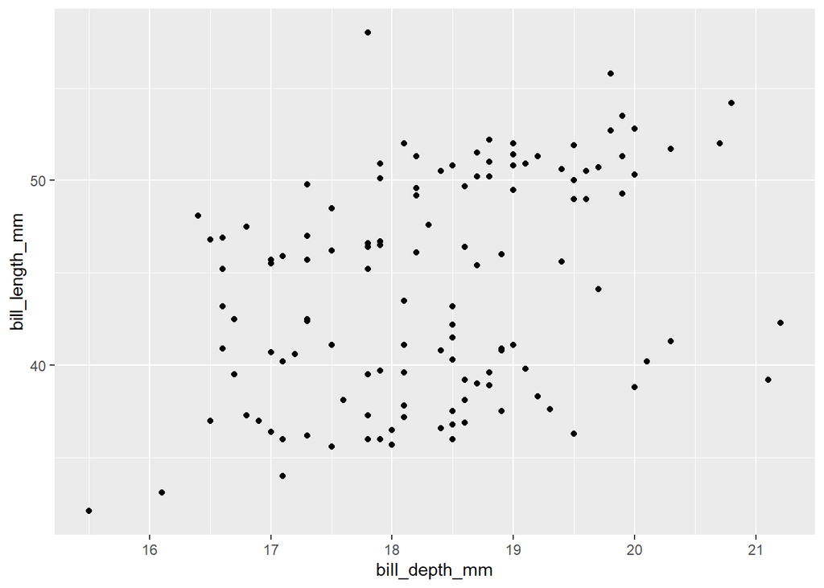

```r
ggplot(Dream_island) +
  aes (x = bill_depth_mm,
       y = bill_length_mm) +
  geom_point()
```

# Lets add color, fill, and shape to the aesthetics so we can visualize data from the different species. We can also add a trend line.

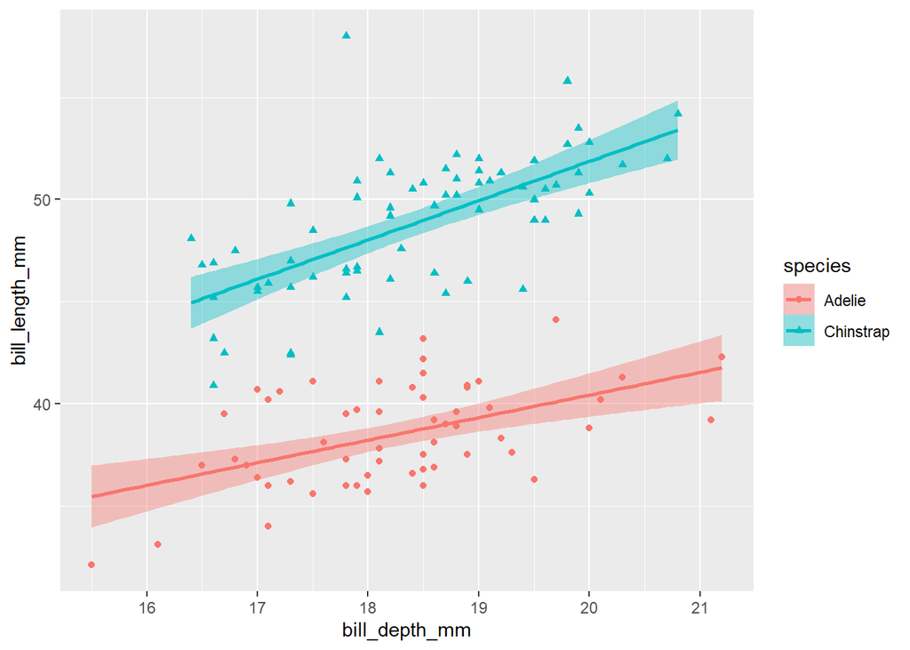

```r
ggplot(Dream_island) +
  aes (x = bill_depth_mm,
       y = bill_length_mm,
       color = species,
       fill = species,
       shape = species) +
  geom_point() +
geom_smooth(method = lm)
```

# Another cool feature of ggplot is themes! I think this data would like cool with a darker theme, lets add it!

# First, lets load the package.

```r
library(hrbrthemes)
```